# Project: Ensemble Techniques - Term Deposit Subscription Prediction

## Multivariate analysis

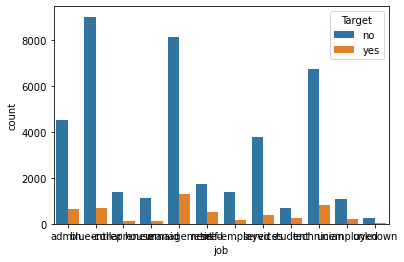

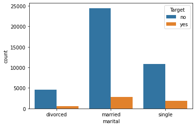

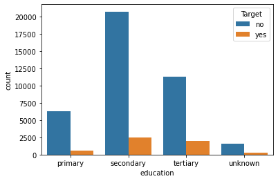

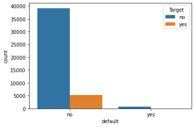

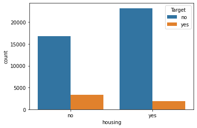

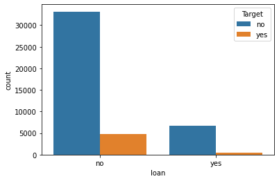

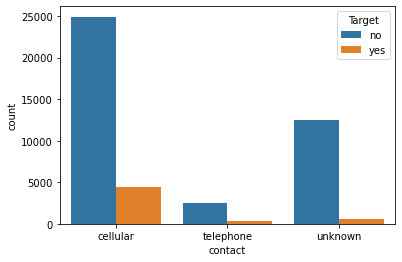

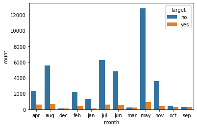

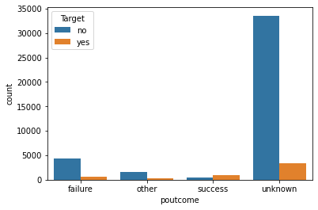

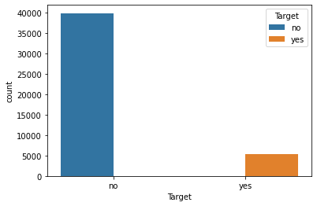

```python
for column in df.columns:
    if df[column].dtype.name == 'category':
        sns.countplot(df[column], hue = df['Target'])
        plt.show()
```

```python
for column in df.columns:
    if df[column].dtype.name == 'category':
        print(pd.crosstab(df[column],df['Target'],normalize='index'))
        print()
```

```
Target               no       yes
job
admin.         0.877973  0.122027
blue-collar    0.927250  0.072750
entrepreneur   0.917283  0.082717
housemaid      0.912097  0.087903
management     0.862444  0.137556
retired        0.772085  0.227915
self-employed  0.881571  0.118429
services       0.911170  0.088830
student        0.713220  0.286780
technician     0.889430  0.110570
unemployed     0.844973  0.155027
unknown        0.881944  0.118056

Target          no       yes
marital
divorced  0.880545  0.119455
married   0.898765  0.101235
single    0.850508  0.149492

Target           no       yes
education
primary    0.913735  0.086265
secondary  0.894406  0.105594
tertiary   0.849936  0.150064
unknown    0.864297  0.135703

Target         no       yes
default
no       0.882039  0.117961
yes      0.936196  0.063804

Target         no       yes
housing
no       0.832976  0.167024
yes      0.923000  0.077000

Target        no       yes
loan
```

[output cut: 20 more lines]

```
nov     0.898489  0.101511
oct     0.562331  0.437669
sep     0.535406  0.464594

Target          no       yes
poutcome
failure   0.873903  0.126097
other     0.833152  0.166848
success   0.352747  0.647253
unknown   0.908385  0.091615

Target   no  yes
Target
no      1.0  0.0
yes     0.0  1.0
```

```python
replaceStruct = {
                "education":     {"unknown": 1, "primary": 2, "secondary": 3, "tertiary": 4 }
                   }
oneHotCols=["job","marital","default","housing","loan","contact","month","poutcome","Target"]
df=df.replace(replaceStruct)
labelencoder = LabelEncoder()
for column in oneHotCols:
    df[column] = labelencoder.fit_transform(df[column])
```

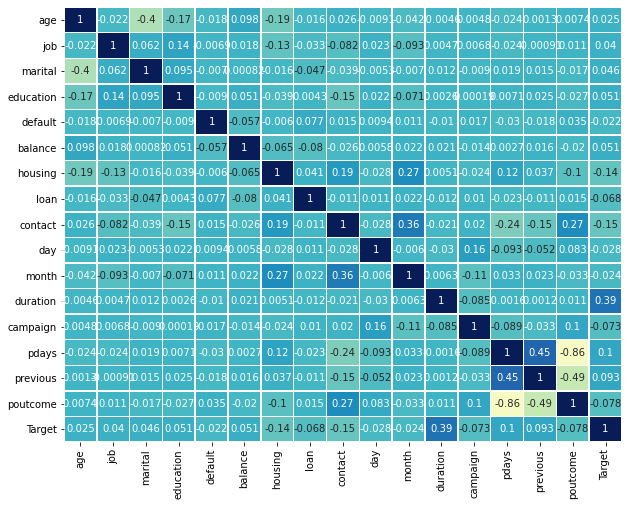

```python
plt.figure(figsize=(10,8))

sns.heatmap(df.corr(),
            annot=True,
            linewidths=.5,
            center=0,
            cbar=False,
            cmap="YlGnBu")

plt.show()
```

## Conclusions from Univariate Analysis

- 11.7% of the population subscribed to the term deposit. Looking at the countplot and cross tab for categorical variables we can make few concusions.
1. Retired people and students are more likely to take term deposit
2. People with existing defaults or loans are less likely to take the term depsoit
3. Calls made in March, September and October had high hit ratio. But this seems to be outliers since less calls were made in these months.
4. Last contact duration has a positive impact in hit ratio.
5. Housing contact and pdaay are having reasonable impact on target outcome

## DecisionTreeClassifier

```python
# splitting data into training and test set for independent attributes
X_train, X_test, y_train, y_test =train_test_split(df.drop('Target',axis=1), df['Target'], test_size=.30, random_state=12)
X_train.shape,X_test.shape
```

```
((31647, 16), (13564, 16))
```

```python
y_train.shape,y_test.shape
```

```
((31647,), (13564,))
```

```python
# print confusion matrix in graphic formatcm = confusion_matrix(y_test, y_pred)
def draw_cm( actual, predicted ):
    cm = confusion_matrix( actual, predicted)
    sns.heatmap(cm, annot=True,  fmt='.2f', xticklabels = [0,1] , yticklabels = [0,1] )
    plt.ylabel('Observed')
    plt.xlabel('Predicted')
    plt.show()
```

```python
model_entropy=DecisionTreeClassifier(criterion='entropy', random_state = 12)
model_entropy.fit(X_train, y_train)
training_acc_DT = model_entropy.score(X_train, y_train)
training_acc_DT
```

```
1.0
```

```python
test_acc_DT= model_entropy.score(X_test, y_test)
y_pred = model_entropy.predict(X_test)
test_acc_DT
```

```
0.8765850781480389
```

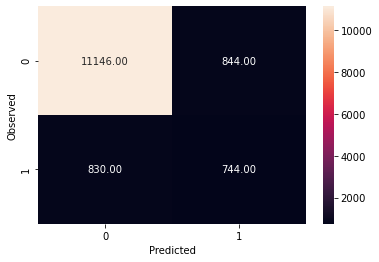

```
None
```

```python
print(draw_cm(y_test,y_pred))
```

```python
training_accuracy =  model_entropy.score(X_train,y_train)
test_accuracy = model_entropy.score(X_test, y_test)
print("Trainig accuracy",training_accuracy)
print()
print("Testing accuracy",test_accuracy)
print()
print("Recall:",recall_score(y_test,y_pred))
print()
print("Precision:",precision_score(y_test,y_pred))
```

```
Trainig accuracy 1.0

Testing accuracy 0.8765850781480389

Recall: 0.4726810673443456

Precision: 0.46851385390428213
```

```python
result_df = pd.DataFrame(columns=['Method', 'Training Accuracy', 'Test Accuracy'])
result_df = result_df.append({'Method':'Decision Tree', 'Training Accuracy': training_accuracy, 'Test Accuracy': test_accuracy}, ignore_index=True)
result_df
```

|  | Method | Training Accuracy | Test Accuracy |
| --- | --- | --- | --- |
| 0 | Decision Tree | 1.0 | 0.876585 |

### The model is overfirtiing with 100% training accuracy and 87% test accuracy

- We need to prune the classifier . Let us try with a depth of 3 and min_samples_leaf=5

```python
model_pruned = DecisionTreeClassifier(criterion='entropy', random_state = 12, max_depth=3, min_samples_leaf=5)
model_pruned.fit(X_train, y_train)
training_acc_DT_prune = model_pruned.score(X_train, y_train)
y_pred = model_pruned.predict(X_test)
```

```python
test_acc_DT_prune = model_pruned.score(X_test, y_test)
```

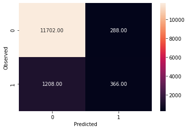

```
None
```

```python
print(draw_cm(y_test,y_pred))
```

```python
training_accuracy =  model_pruned.score(X_train,y_train)
test_accuracy = model_pruned.score(X_test, y_test)
print("Trainig accuracy",training_accuracy)
print()
print("Testing accuracy",test_accuracy)
print()
print("Recall:",recall_score(y_test,y_pred))
print()
print("Precision:",precision_score(y_test,y_pred))
result_df = result_df.append({'Method':'Decision Tree Pruned', 'Training Accuracy': training_accuracy, 'Test Accuracy': test_accuracy}, ignore_index=True)
result_df
```

```
Trainig accuracy 0.8887098303156697

Testing accuracy 0.8897080507225007

Recall: 0.23252858958068615

Precision: 0.5596330275229358
```

|  | Method | Training Accuracy | Test Accuracy |
| --- | --- | --- | --- |
| 0 | Decision Tree | 1.00000 | 0.876585 |
| 1 | Decision Tree Pruned | 0.88871 | 0.889708 |

### The DecisionTreeClassifier is giving 88% accuracy on both training and testing data after pruning. There is no overfitting now.

## Logistic Regression

```python
reg = LogisticRegression()
reg.fit(X_train, y_train)
```

```
LogisticRegression()
```

```python
# predict y for the test set
y_pred = reg.predict(X_test)
```

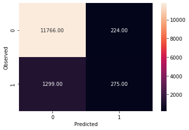

```
None
```

```python
print(draw_cm(y_test,y_pred))
```

```python
training_accuracy =  reg.score(X_train,y_train)
test_accuracy = reg.score(X_test, y_test)
print("Trainig accuracy",training_accuracy)
print()
print("Testing accuracy",test_accuracy)
print()
print("Recall:",recall_score(y_test,y_pred))
print()
print("Precision:",precision_score(y_test,y_pred))
result_df = result_df.append({'Method':'Logistic Regression', 'Training Accuracy': training_accuracy, 'Test Accuracy': test_accuracy}, ignore_index=True)
result_df
```

```
Trainig accuracy 0.8871615003001865

Testing accuracy 0.887717487466824

Recall: 0.17471410419313851

Precision: 0.5511022044088176
```

|  | Method | Training Accuracy | Test Accuracy |
| --- | --- | --- | --- |
| 0 | Decision Tree | 1.000000 | 0.876585 |
| 1 | Decision Tree Pruned | 0.888710 | 0.889708 |
| 2 | Logistic Regression | 0.887162 | 0.887717 |

### The Logistic regression is giving similar accuracy as of decision tree with pruning. There is no overfitting with LogisticRegression

## AdaBoostClassifier

```python
abcl = AdaBoostClassifier(n_estimators = 100, learning_rate=0.1, random_state=12)
abcl = abcl.fit(X_train, y_train)
```

```python
y_pred =abcl.predict(X_test)
```

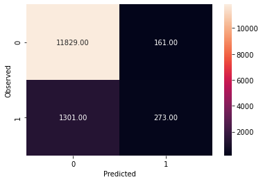

```
None
```

```python
print(draw_cm(y_test,y_pred))
```

```python
training_accuracy =  abcl.score(X_train,y_train)
test_accuracy = abcl.score(X_test, y_test)
print("Trainig accuracy",training_accuracy)
print()
print("Testing accuracy",test_accuracy)
print()
print("Recall:",recall_score(y_test,y_pred))
print()
print("Precision:",precision_score(y_test,y_pred))
result_df = result_df.append({'Method':'AdaBoostClassifier', 'Training Accuracy': training_accuracy, 'Test Accuracy': test_accuracy}, ignore_index=True)
result_df
```

```
Trainig accuracy 0.8889626188896262

Testing accuracy 0.892214685933353

Recall: 0.17344345616264295

Precision: 0.6290322580645161
```

|  | Method | Training Accuracy | Test Accuracy |
| --- | --- | --- | --- |
| 0 | Decision Tree | 1.000000 | 0.876585 |
| 1 | Decision Tree Pruned | 0.888710 | 0.889708 |
| 2 | Logistic Regression | 0.887162 | 0.887717 |
| 3 | AdaBoostClassifier | 0.888963 | 0.892215 |

### The AdaBoostClassifier gives similar accuracy comapred to decistion tree with pruning and LogisticRegression

## BaggingClassifier

```python
bgcl = BaggingClassifier(n_estimators=50, max_samples= .7, bootstrap=True, oob_score=True, random_state=12)
bgcl = bgcl.fit(X_train, y_train)
```

```python
y_pred = bgcl.predict(X_test)
acc_BG = accuracy_score(y_test, y_pred)
```

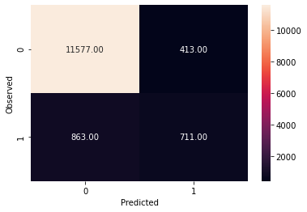

```
None
```

```python
print(draw_cm(y_test,y_pred))
```

```python
training_accuracy =  bgcl.score(X_train,y_train)
test_accuracy = bgcl.score(X_test, y_test)
print("Trainig accuracy",training_accuracy)
print()
print("Testing accuracy",test_accuracy)
print()
print("Recall:",recall_score(y_test,y_pred))
print()
print("Precision:",precision_score(y_test,y_pred))
result_df = result_df.append({'Method':'BaggingClassifier', 'Training Accuracy': training_accuracy, 'Test Accuracy': test_accuracy}, ignore_index=True)
result_df
```

```
Trainig accuracy 0.9933327013618984

Testing accuracy 0.9059274550280153

Recall: 0.45171537484116897

Precision: 0.6325622775800712
```

|  | Method | Training Accuracy | Test Accuracy |
| --- | --- | --- | --- |
| 0 | Decision Tree | 1.000000 | 0.876585 |
| 1 | Decision Tree Pruned | 0.888710 | 0.889708 |
| 2 | Logistic Regression | 0.887162 | 0.887717 |
| 3 | AdaBoostClassifier | 0.888963 | 0.892215 |
| 4 | BaggingClassifier | 0.993333 | 0.905927 |

# Comarison of results and conclusion

```python
result_df
```

|  | Method | Training Accuracy | Test Accuracy |
| --- | --- | --- | --- |
| 0 | Decision Tree | 1.000000 | 0.876585 |
| 1 | Decision Tree Pruned | 0.888710 | 0.889708 |
| 2 | Logistic Regression | 0.887162 | 0.887717 |
| 3 | AdaBoostClassifier | 0.888963 | 0.892215 |
| 4 | BaggingClassifier | 0.993333 | 0.905927 |

- Bagging classifier is overfitting
- Ada boost, logistic regression and decision tree with pruning provides comparable results